# Modern Regression

2023-03-29

## Source

The R codes for the baseball example and the data are taken from the ISLR book by James, Witten, Hastie and Tibshirani.

This is a low-dimensional example, which means \(p < n\). We will see how LASSO and Ridge compares with OLS on this data-set.

We will see a high-dimensional example after this. Of course, there isn’t a unique OLS for high-dimensional data.

## Baseball data

Major League Baseball Data from the 1986 and 1987 seasons.

```r
library(ISLR)
#fix(Hitters)
names(Hitters)
```

```
##  [1] "AtBat"     "Hits"      "HmRun"     "Runs"      "RBI"       "Walks"
##  [7] "Years"     "CAtBat"    "CHits"     "CHmRun"    "CRuns"     "CRBI"
## [13] "CWalks"    "League"    "Division"  "PutOuts"   "Assists"   "Errors"
## [19] "Salary"    "NewLeague"
```

```r
dim(Hitters)
```

```
## [1] 322  20
```

## Variables

- `AtBat`: Number of times at bat in 1986, `Hits`: Number of hits in 1986
- `HmRun`: Number of home runs in 1986, `Runs`: Number of runs in 1986
- `RBI`: Number of runs batted in in 1986, `Walks`: Number of walks in 1986.
- `Years`: Number of years in the major leagues
- `CAtBat`: Number of times at bat during his career
- `CHits`: Number of hits during his career
- `CHmRun`: Number of home runs during his career
- `CRuns`: Number of runs during his career
- `CRBI`: Number of runs batted in during his career
- `CWalks`: Number of walks during his career
- `League`: A factor with levels A and N indicating player’s league at the end of 1986
- `Division`: A factor with levels E and W indicating player’s division at the end of 1986
- `PutOuts`: Number of put outs in 1986
- `Assists`: Number of assists in 1986
- `Errors`: Number of errors in 1986
- `Salary`: 1987 annual salary on opening day in thousands of dollars
- `NewLeague`: A factor with levels A and N indicating player’s league at the beginning of 1987

## Remove NA’s

Salary is missing for some players. The `na.omit()` function removes all of the rows that have missing values in any variable.

```r
sum(is.na(Hitters$Salary))
```

```
## [1] 59
```

```r
Hitters=na.omit(Hitters)
dim(Hitters)
```

```
## [1] 263  20
```

## Load a few extra packages

```r
## prevent scientific notation
options(scipen = 100, digits = 4)

# Set the graphical theme
ggplot2::theme_set(ggplot2::theme_light())

# Helper packages
library(recipes)  # for feature engineering

# Modeling packages
library(glmnet)   # for implementing regularized regression
library(caret)    # for automating the tuning process

# Model interpretability packages
library(vip)      # for variable importance
```

## Linear regression

- In OLS regression, the goal is to identify the hyperplane that minimizes the sum of squared errors (SSE or RSS) between the predicted and observed response values.
- This involves minimizing the vertical distance between the predicted (blue line) and observed (red dots) response values, which is represented by the grey lines.

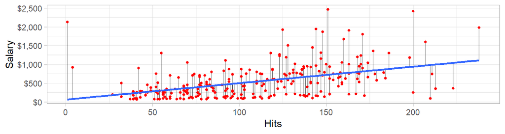

## Bet on Sparsity

- Classic regression models face issues with large number of features.
- Large number of features makes the model less interpretable.
- When \(p > n\), there are infinite solutions to the OLS problem.
- It is useful and practical to assume that a smaller subset of features have the strongest effects.
- This assumption is known as the “bet on sparsity” principle, introduced by Hastie, Tibshirani, and Wainwright in 2015.

## Feature selection

- Two approaches to address large number of features: hard thresholding and soft thresholding.
- Hard thresholding includes traditional linear model selection methods like forward selection and backward elimination.
- Soft thresholding is a more modern approach that slowly pushes irrelevant features toward zero, resulting in more accurate and interpretable models.
- Soft thresholding can zero out entire coefficients and is more efficient and scalable than hard thresholding.

## Penalty

- Regularized regression model has an objective function similar to OLS, but with a penalty term P that constrains the size of coefficients.

\[ \text{minimize}(RSS + P) \]

- Coefficients can only increase if there is a comparable decrease in the residual sum of squares (RSS) or sum of squared errors (SSE).
- This concept applies to all GLM models, including logistic and Poisson regression, and some survival models, even though different GLM models may have different loss functions.
- The penalty parameter constrains the size of coefficients such that they can only increase if there is a comparable decrease in the model’s loss function.
- There are three common penalty parameters we can implement:
1. Ridge: \(P = \lambda \sum_{i=1}^{p}\beta_i^2\).
2. Lasso (or LASSO): \(P = \lambda \sum_{i=1}^{p}\lvert \beta_i \rvert\).
3. Elastic net (or ENET): \(P = \lambda_1 \sum_{i=1}^{p}\beta_i^2 + \lambda_2 \sum_{i=1}^{p}\lvert \beta_i \rvert\).

## Ridge Regression

- Ridge, Lasso, Elastic Net are all based on R package `glmnet`.
- Elastic Net Penalty: \[ P_{\lambda,\alpha}(\beta) = \lambda \left \{ \frac{(1-\alpha)}{2} {\lVert \beta \rVert}_2^2 + \alpha {\lVert \beta \rVert}_1^2 \right \} \]
- \(\alpha = 0\) is Ridge, \(\alpha = 1\) is Lasso, anything in between (\(0 < \alpha < 1\) is called Elastic Net.
- \(\lambda = 0\) is ordinary least squares.
- ‘Elastic Net’ is a mix of Lasso and Ridge - it works better when the predictor variables are ‘grouped’.
- All the three methods can be fit using the `glmnet` package.

## R commands

```r
x=model.matrix(Salary~.,Hitters)[,-1]
y=Hitters$Salary
dim(x)
```

```
## [1] 263  19
```

```r
length(y)
```

```
## [1] 263
```

## Fitting Ridge

- We’ll specify \(\alpha = 0\) and calculate the ridge solution for \(100\) different values of \(\lambda\), chosen by us.

```r
library(glmnet)
grid=10^seq(10,-2,length=100)
ridge.mod=glmnet(x,y,alpha=0,lambda=grid)
dim(coef(ridge.mod))
```

```
## [1]  20 100
```

## Dependence on \(\lambda\)

- When \(\lambda\) = 811130830.7897, check that the magnitude of the \(\beta\) coefficients are small.

```r
ridge.mod$lambda[10]
```

```
## [1] 811130831
```

```r
coef(ridge.mod)[,10]
```

```
##     (Intercept)           AtBat            Hits           HmRun            Runs
## 535.92355688461   0.00000067109   0.00000243436   0.00000980914   0.00000411668
##             RBI           Walks           Years          CAtBat           CHits
##   0.00000434851   0.00000511793   0.00002093010   0.00000005762   0.00000021206
##          CHmRun           CRuns            CRBI          CWalks         LeagueN
##   0.00000159921   0.00000042543   0.00000043906   0.00000046452  -0.00000715069
##       DivisionW         PutOuts         Assists          Errors      NewLeagueN
##  -0.00009625147   0.00000026880   0.00000004390  -0.00000020471  -0.00000142049
```

- and the value of \(\sum_{i=1}^{p}\beta_i^2\) is also quite small.

```r
sqrt(sum(coef(ridge.mod)[-1,10]^2))
```

```
## [1] 0.00009962
```

## Dependence on \(\lambda\)

- Now, we decrease \(\lambda\) to \(\lambda\) = 11497.57.
- check that the magnitude of the \(\beta\) coefficients and the value of \(\sum_{i=1}^{p}\beta_i^2\) has increased a bit.
- We are regularizing **less** than before!

```r
ridge.mod$lambda[50]
```

```
## [1] 11498
```

```r
coef(ridge.mod)[,50]
```

```
## (Intercept)       AtBat        Hits       HmRun        Runs         RBI
##  407.356050    0.036957    0.138180    0.524630    0.230702    0.239841
##       Walks       Years      CAtBat       CHits      CHmRun       CRuns
##    0.289619    1.107703    0.003132    0.011654    0.087546    0.023380
##        CRBI      CWalks     LeagueN   DivisionW     PutOuts     Assists
##    0.024138    0.025015    0.085028   -6.215441    0.016483    0.002613
##      Errors  NewLeagueN
##   -0.020503    0.301434
```

```r
sqrt(sum(coef(ridge.mod)[-1,50]^2))
```

```
## [1] 6.361
```

## Dependence on \(\lambda\)

- Now, we have a small \(\lambda\): \(\lambda\) = 0.01 :

```r
ridge.mod$lambda[100]
```

```
## [1] 0.01
```

```r
coef(ridge.mod)[,100]
```

```
## (Intercept)       AtBat        Hits       HmRun        Runs         RBI
##   164.11322    -1.97386     7.37772     3.93660    -2.19874    -0.91623
##       Walks       Years      CAtBat       CHits      CHmRun       CRuns
##     6.20038    -3.71403    -0.17510     0.21133     0.05629     1.36605
##        CRBI      CWalks     LeagueN   DivisionW     PutOuts     Assists
##     0.70966    -0.79582    63.40493  -117.08244     0.28203     0.37318
##      Errors  NewLeagueN
##    -3.42400   -25.99082
```

```r
sqrt(sum(coef(ridge.mod)[-1,100]^2))
```

```
## [1] 136.2
```

- As you can see, the magnitudes of \(\beta_j\)’s and the sum of square norm has increased signficantly.
- Somewhere in this spectrum lies the optimal \(\beta\): find out using CV.

## Solution path

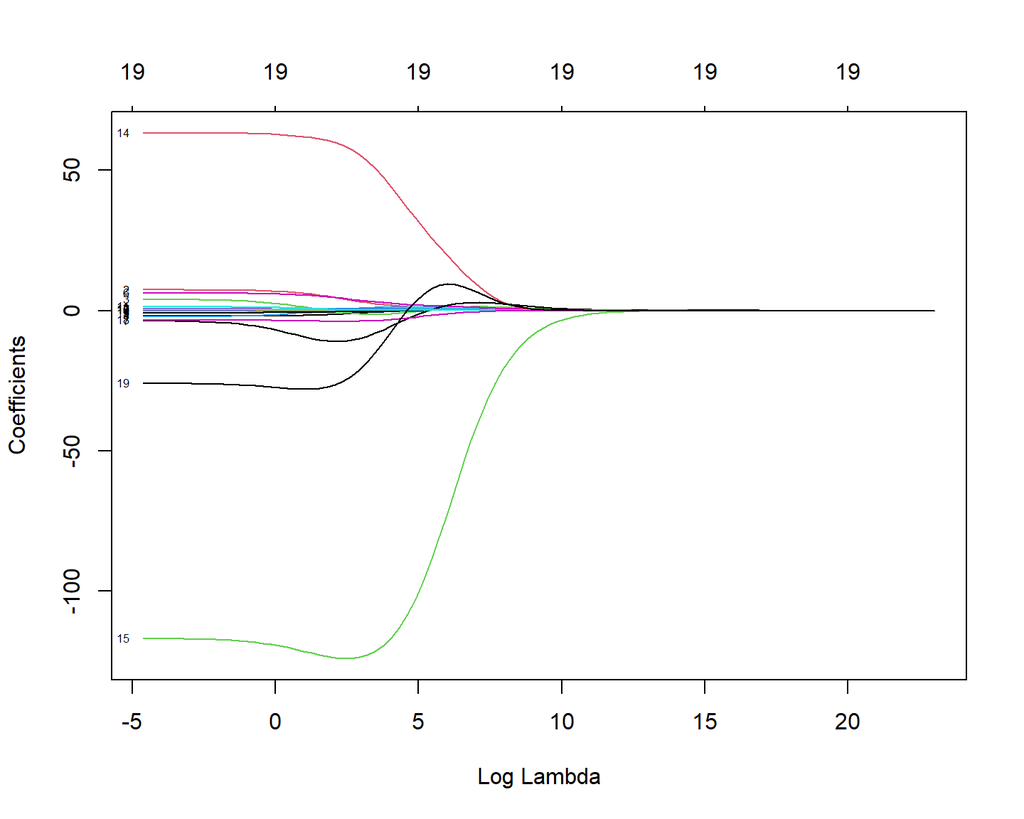

```r
plot(ridge.mod,xvar="lambda",label=TRUE)
```

## Choosing the best solution

- We will use cross-validation to choose the best \(\lambda\) that minimizes the test error.
- We have discussed LOO-CV and \(k\)-fold CV in class. In general, LOO-CV has higher variance but \(k\)-fold is more stable.
- We’ll first use a single validation set and then show CV.
- Also, note that if you are splitting randomly, you should **fix the random number generating seed** to reproduce your results.

## Ridge with CV

- Now split the samples into a training set and a test set in order to estimate the test error of ridge regression.
- Two ways to split:
  1. Produce a random vector of `TRUE`, `FALSE` elements and select the observations corresponding to `TRUE` for the training data.
  2. Randomly choose a subset of numbers between 1 and n - these can then be used as the indices for the training observations.

## Traing and Test

```r
set.seed(1)
train=sample(1:nrow(x), nrow(x)/2)
test=(-train)
y.test=y[test]
dim(x[train,])
```

```
## [1] 131  19
```

```r
dim(x[test,])
```

```
## [1] 132  19
```

## Fit on training, evaluate on test

- Next we fit a ridge regression model on the training set, and evaluate its MSE on the test set, using \(\lambda = 4\).
- The `predict()` function : here we get predictions for a test set, by replacing `type="coefficients"` with the `newx` argument.
- Specify `s = 4` to fix \(\lambda = 4\).

```r
ridge.mod=glmnet(x[train,],y[train],alpha=0,lambda=grid, thresh=1e-12)
ridge.pred=predict(ridge.mod,s=4,newx=x[test,])
mean((ridge.pred-y.test)^2)
```

```
## [1] 142199
```

- Note: \(\lambda = 4\) is an arbitrary value I have chosen for illustration. The optimal \(\lambda\) will be chosen by CV a few slides later.

## Fit

The test MSE is 142199.1507

If we had instead simply fit a model with just an intercept, we would have predicted each test observation using the mean of the training observations:

```r
mean((mean(y[train])-y.test)^2)
```

```
## [1] 224670
```

## Another way

- We could also get the same result by fitting a ridge regression model with a very large value of \(\lambda\). Note that `s=1e10` means \(\lambda = 10^{10}\).

```r
null.pred=predict(ridge.mod,s=1e10,newx=x[test,])
mean((null.pred-y.test)^2)
```

```
## [1] 224670
```

- So fitting a ridge regression model with \(\lambda = 4\) leads to a much lower test MSE than fitting a model with just an intercept.

## Obtaining least squres

- Is it better than just performing least squares regression?
- Ridge regression reduces to OLS for \(\lambda = 0\).

```r
ols.pred=predict(ridge.mod,s=0,newx=x[test,])
mean((ols.pred-y.test)^2)
```

```
## [1] 167790
```

- Ridge Regression MSE was 142199.1507.
- OLS has MSE 167789.7784

## CV to choose \(\lambda\)

- In general, instead of arbitrarily choosing \(\lambda = 4\), it would be better to use cross-validation to choose the tuning parameter.
- We can do this using the built-in cross-validation function, `cv.glmnet()`.
- By default, the function `cv.glmnet()` performs ten-fold cross-validation, though this can be changed using the argument `nfolds`.

## Best lambda

Setting a random seed is important for reproducibility.

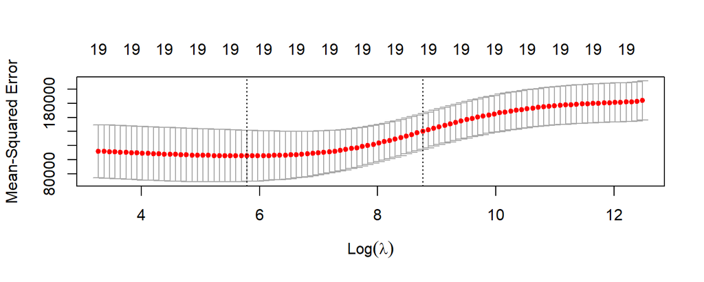

```r
set.seed(1)
cv.out=cv.glmnet(x[train,],y[train],alpha=0)
plot(cv.out)
```

## Best lambda

```r
bestlam=cv.out$lambda.min
bestlam
```

```
## [1] 326.1
```

The value of \(\lambda\) that yields lowest CV error is 326.0828, very different from 4.

## What happens to the MSE?

We should calculate the test error at this “best” \(\lambda\) and check if it’s improving the fit.

```r
bestlam=cv.out$lambda.min
bestlam
```

```
## [1] 326.1
```

```r
ridge.pred=predict(ridge.mod,s=bestlam,newx=x[test,])
mean((ridge.pred-y.test)^2)
```

```
## [1] 139857
```

- It does reduce the test MSE.

## The Coefficients

```r
out=glmnet(x,y,alpha=0)
predict(out,type="coefficients",s=bestlam)[1:20,]
```

```
## (Intercept)       AtBat        Hits       HmRun        Runs         RBI
##    15.44383     0.07716     0.85912     0.60103     1.06369     0.87936
##       Walks       Years      CAtBat       CHits      CHmRun       CRuns
##     1.62445     1.35255     0.01135     0.05747     0.40680     0.11456
##        CRBI      CWalks     LeagueN   DivisionW     PutOuts     Assists
##     0.12117     0.05299    22.09143   -79.04033     0.16620     0.02942
##      Errors  NewLeagueN
##    -1.36093     9.12488
```

- As expected, none of the coefficients are zero : Ridge regression does not perform any variable selection.

## Variable Importance

- Variable importance for regularized models provides a similar interpretation as in linear (or logistic) regression. Importance is determined by magnitude of the standardized coefficients

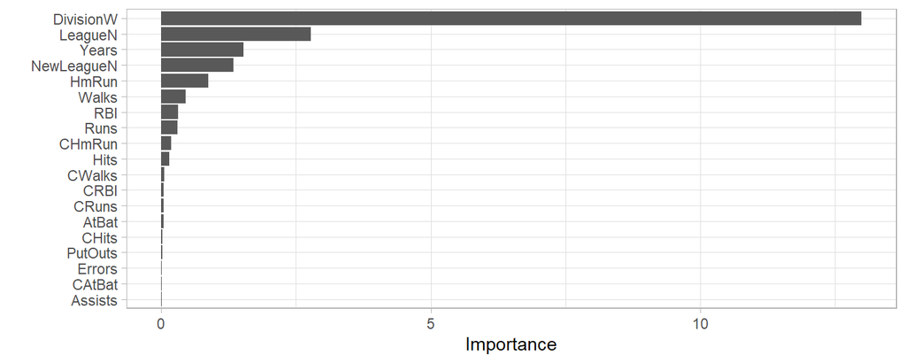

```r
vip(cv.out, num_features = 20, bar = FALSE) + theme_light()
```

## Lasso

## Lasso Penalty

- Recall: Ridge, Lasso, Elastic Net are all based on R package `glmnet`.
- Elastic Net Penalty: \[ P_{\lambda,\alpha}(\beta) = \lambda \left \{ \frac{(1-\alpha)}{2} {\lVert \beta \rVert}_2^2 + \alpha {\lVert \beta \rVert}_1^2 \right \} \]
- \(\alpha = 0\) is Ridge, \(\alpha = 1\) is Lasso, anything in between is Elastic Net.
- All we need to do is change `alpha = 1` in `glmnet` function call.

## Lasso in R

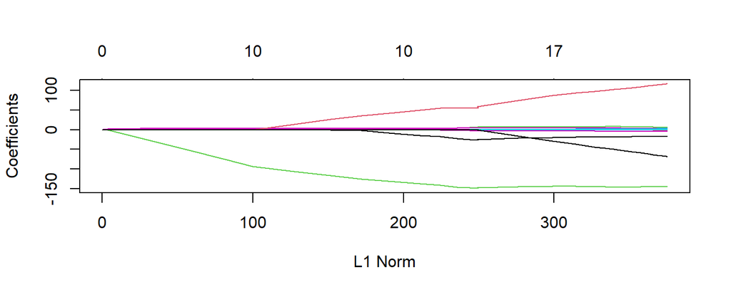

```r
lasso.mod =glmnet (x[train ,], y[train], alpha = 1, lambda = grid)
plot(lasso.mod)
```

## Choosing lambda by 10-fold CV

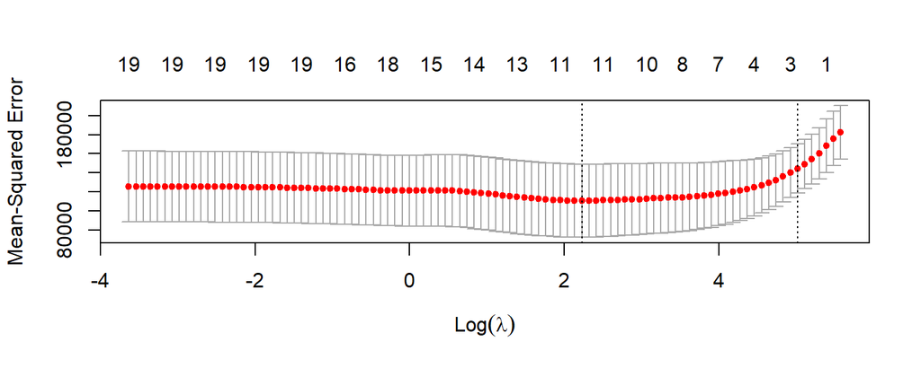

```r
set.seed (1)
cv.out =cv.glmnet( x[train ,], y[train], alpha = 1)
plot(cv.out)
```

## Choosing lambda by 10-fold CV

```r
bestlam =cv.out$lambda.min
lasso.pred=predict(lasso.mod, s = bestlam , newx = x[test,])
mean((lasso.pred - y.test)^2)
```

```
## [1] 143674
```

This is substantially lower than the test set MSE of the null model and of least squares, and very similar to the test MSE of ridge regression with \(\lambda\) chosen by cross-validation.

## Sparse Model

```r
out=glmnet (x,y, alpha = 1, lambda =grid)
lasso.coef=predict(out, type = "coefficients", s = bestlam )[1:20,]
lasso.coef
```

```
## (Intercept)       AtBat        Hits       HmRun        Runs         RBI
##     1.27479    -0.05497     2.18035     0.00000     0.00000     0.00000
##       Walks       Years      CAtBat       CHits      CHmRun       CRuns
##     2.29192    -0.33806     0.00000     0.00000     0.02825     0.21628
##        CRBI      CWalks     LeagueN   DivisionW     PutOuts     Assists
##     0.41713     0.00000    20.28615  -116.16756     0.23752     0.00000
##      Errors  NewLeagueN
##    -0.85629     0.00000
```

## Sparse Model

```r
lasso.coef[lasso.coef !=0]
```

```
## (Intercept)       AtBat        Hits       Walks       Years      CHmRun
##     1.27479    -0.05497     2.18035     2.29192    -0.33806     0.02825
##       CRuns        CRBI     LeagueN   DivisionW     PutOuts      Errors
##     0.21628     0.41713    20.28615  -116.16756     0.23752    -0.85629
```

## Large \(p\), small \(n\)

- Generate \(X\), \(y\) with \(n = 30, p = 60\) with a sparse \(\beta\) vector with 5 non-zero elements.
- Generate \(X\) matrix as \(n \times p\) matrix with all entries from a \(N(0,1)\) distribution.
- Take \(\beta = (3,\ldots,3, 0, \ldots, 0)\), and a small error distribution \(\epsilon \sim N(0,0.1)\).

## Generating the data

```r
library(Matrix)
set.seed(12345)
n = 30;p = 60
p1 = 5
beta <- c(rep(3,p1),rep(0,p-p1))
x=scale(matrix(rnorm(n*p),n,p))
eps=rnorm(n,mean=0,sd = 0.1)
fx = x %*% beta
y=drop(fx+eps)
```

- Our goal is to see if Lasso can recover the 5 non-zero \(\beta\)’s correctly.

## Ordinary Least Squares

- The OLS Solution will not work here, as expected.

```r
xtx = t(x)%*%x
y1 <- t(x) %*% y
betahat.1 <- solve(xtx,y1)
```

```
## Error in solve.default(xtx, y1): system is computationally singular: reciprocal condition number = 8.24087e-19
```

## Does Pseudo-Inverse Work?

The Moore-Penrose g-inverse is unstable and does not recover the true sparsity pattern.

```r
library(MASS)
xtx = t(x)%*%x
y1 <- t(x) %*% y
xtx <- as.matrix(xtx)
betahat <- ginv(xtx) %*% y1
t(betahat)
```

```
##       [,1]  [,2]  [,3]  [,4]  [,5]    [,6]   [,7]   [,8]    [,9]   [,10]
## [1,] 1.609 2.055 2.008 1.483 2.075 -0.3615 0.7423 0.6313 -0.5369 -0.6536
##        [,11]  [,12]  [,13] [,14]   [,15]   [,16]   [,17]  [,18]  [,19]  [,20]
## [1,] -0.4607 0.3531 0.2274 0.226 -0.4165 -0.1229 -0.9068 0.1028 -0.665 0.1945
##      [,21]    [,22]  [,23]   [,24]  [,25]  [,26]   [,27]   [,28]  [,29]
## [1,] 0.197 0.006585 0.5017 -0.1722 0.1779 0.3186 -0.3519 -0.6238 0.1718
##         [,30]  [,31]  [,32]   [,33]  [,34]   [,35]   [,36]    [,37]  [,38]
## [1,] -0.05045 0.5132 0.4553 -0.2887 0.2955 -0.5663 -0.1818 -0.09759 0.1951
##        [,39]  [,40]   [,41]  [,42]  [,43]  [,44]  [,45]  [,46]   [,47]    [,48]
## [1,] -0.5981 0.4919 0.02024 -0.158 0.2579 0.4575 -1.059 0.1265 -0.2224 -0.01835
##       [,49]   [,50]  [,51]  [,52]   [,53]  [,54]    [,55]   [,56]   [,57]
## [1,] 0.4381 -0.7195 0.3673 0.6158 -0.5537 0.3277 0.006263 0.02666 -0.2797
##        [,58]   [,59]   [,60]
## [1,] -0.7236 -0.1992 -0.1381
```

## The g-Inverse estimate

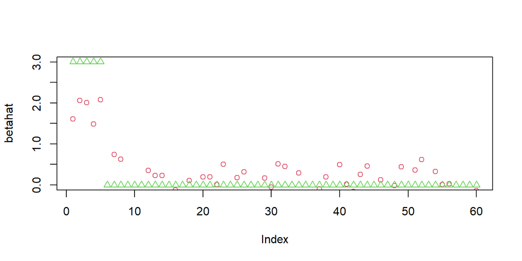

```r
plot(betahat,col=2,ylim=c(0,3), pch = 1)
points(beta,col= 3, pch = 2)
legend(75,2,c("G-inv","True"),col=c(2,3),pch=c(1,2))
```

## Enter Lasso

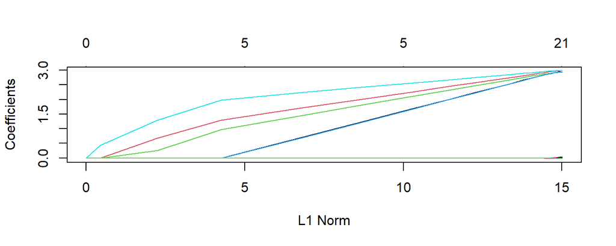

```r
grid=10^seq(10,-2,length=100)
lasso.mod =glmnet(x,y,alpha =1,lambda =grid)
plot(lasso.mod)
```

## Choosing Lambda

```r
cv.out =cv.glmnet(x,y,alpha =1)
(bestlam =cv.out$lambda.min)
```

```
## [1] 0.08296
```

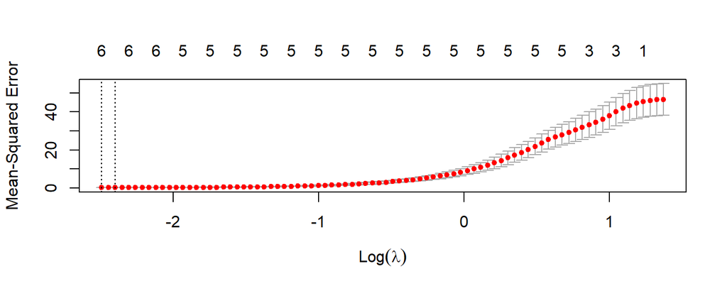

```r
plot(cv.out)
```

## Sparse Solution

```r
lasso.coef=predict(lasso.mod,type ="coefficients",s=bestlam)
lasso.coef[lasso.coef !=0]
```

```
## [1]  0.0146  2.8567  2.9295  2.8817  2.8510  2.9623 -0.0144
```

- Use `which` function to get rid of the warning message

```r
lasso.coef[which(lasso.coef!=0)]
```

```
## [1]  0.0146  2.8567  2.9295  2.8817  2.8510  2.9623 -0.0144
```

## Lasso is close to the truth

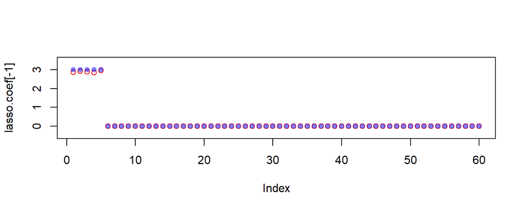

```r
plot(lasso.coef[-1],col="red", pch = 1, ylim = c(-0.5,3.5))
points(beta,col= rgb(0,0,1,0.5),pch = 16)
legend(75,2,c("Lasso","True"),col=c("red","blue"),pch=c(17,16))
```